# Análise Sensorial Hedônica – Feira Mostaqui

Produtos Derivados de Pescado | UFOPA – Campus Monte Alegre

Laboratório de Análise Sensorial

27 de maio de 2026

> **Escala hedônica utilizada:** 1 = Desgostei Muito → 5 = Gostei Muito  
> **Limiar de aceitabilidade:** Índice de Aceitabilidade (IA%) ≥ 70%

# 1 Pacotes e Configuração

```r
# Instale os pacotes caso necessário:
# install.packages(c("readxl","dplyr","tidyr","ggplot2","scales",
#                    "ggpubr","rstatix","corrplot","RColorBrewer",
#                    "patchwork","psych","MASS","tibble","stringr"))

suppressPackageStartupMessages({
  library(readxl)
  library(dplyr)
  library(tidyr)
  library(ggplot2)
  library(scales)
  library(ggpubr)
  library(rstatix)
  library(corrplot)
  library(RColorBrewer)
  library(patchwork)
  library(psych)
  library(MASS)      # polr() – regressão ordinal
  library(tibble)
  library(stringr)
})

set.seed(42)
```

> **Por que esses pacotes?**  
> O conjunto utilizado cobre toda a pipeline analítica: `readxl` lê dados do Excel; `dplyr`/`tidyr` fazem a limpeza e transformação; `ggplot2` + `ggpubr` + `patchwork` geram as figuras; `rstatix` executa testes não-paramétricos de forma *tidy*; `psych` fornece estatísticas descritivas ampliadas; `MASS` ajusta a regressão ordinal; e `corrplot` visualiza correlações.

# 2 Leitura e Limpeza dos Dados

```r
df_raw <- read_excel("df_mostraqui.xlsx")

# Padroniza nomes (remove espaços, acentos problemáticos)
names(df_raw) <- c("id","entrevistado","grupo","sexo","idade",
                   "amostra","cor","aroma","aparencia","sabor",
                   "impressao","compra","derivados","vezes")

# Converte colunas de pontuação para numérico
df_raw <- df_raw %>%
  dplyr::mutate(across(c(cor, aroma, aparencia, sabor, impressao, compra, vezes),
                       as.numeric))
```

```r
df <- df_raw %>%
  mutate(
    amostra = str_trim(amostra),

    sexo = case_when(
      toupper(str_trim(sexo)) %in% c("F","FEMININO")  ~ "Feminino",
      toupper(str_trim(sexo)) %in% c("M","MASCULINO") ~ "Masculino",
      TRUE                                              ~ NA_character_
    ),

    idade = suppressWarnings(as.numeric(as.character(idade))),

    derivados = case_when(
      toupper(str_trim(derivados)) == "SIM" ~ "Sim",
      toupper(str_trim(derivados)) %in% c("NÃO","NAO","NÃO","NAO","NAOO") ~ "Não",
      TRUE ~ NA_character_
    ),

    faixa_etaria = cut(idade,
                       breaks = c(0, 17, 29, 44, 59, Inf),
                       labels = c("≤17 anos","18–29","30–44","45–59","≥60"),
                       right  = TRUE, include.lowest = TRUE),

    grupo_label = case_when(
      grupo == 2 ~ "Grupo 2\n(Lasanha / Coxinha / Arroz)",
      grupo == 3 ~ "Grupo 3\n(Patê / Farofa / Empada)",
      grupo == 4 ~ "Grupo 4\n(Risole / Hot Fish / Fishburguer)",
      grupo == 5 ~ "Grupo 5\n(Iscas / Brigadeiro)",
      TRUE       ~ paste("Grupo", grupo)
    ),

    hedonico_medio = rowMeans(
      dplyr::select(., cor, aroma, aparencia, sabor, impressao), na.rm = TRUE),

    compra_ord = factor(compra, levels = 1:5,
                        labels = c("Certamente\nnão compraria",
                                   "Possivelmente\nnão compraria",
                                   "Talvez comprasse /\ntalvez não",
                                   "Possivelmente\ncompraria",
                                   "Certamente\ncompraria"),
                        ordered = TRUE),

    aceito = impressao >= 4
  )

# Abreviações para gráficos
abrev_produtos <- c(
  "Arroz Paraense com Polvo"                              = "Arroz c/ Polvo",
  "Brigadeiro de Coco com Pescada"                        = "Brigadeiro c/ Pescada",
  "Coxinha de Rã com creme de queijo regional"            = "Coxinha de Rã",
  "Empada de Tamoatá com creme de queijo regional"        = "Empada de Tamoatá",
  "Farofa de Tambaqui com Banana"                         = "Farofa c/ Banana",
  "Fishburguer de Acari"                                  = "Fishburguer (Acari)",
  "Hot Fish de Tambaqui"                                  = "Hot Fish (Tambaqui)",
  "Isca de Pirapitinga com Doce de Castanha de Caju e Mel"= "Isca (Pirapitinga)",
  "Isca de Pirarucu com Geleia de Cupuaçu Picante"        = "Isca (Pirarucu)",
  "Lasanha de Tucunaré"                                   = "Lasanha (Tucunaré)",
  "Patê de Pirarucu"                                      = "Patê de Pirarucu",
  "Risole de Tambaqui"                                    = "Risole (Tambaqui)"
)

df <- df %>%
  mutate(produto_abrev = recode(amostra, !!!abrev_produtos))
```

## 2.1 Qualidade dos dados

### 2.1.1 Resumo Geral

```r
cat(sprintf("Avaliações totais:   %d\n", nrow(df)))
```

```
## Avaliações totais:   1154
```

```r
cat(sprintf("Avaliadores únicos:  %d (somando todos os grupos)\n",
            sum(sapply(unique(df$grupo),
                       function(g) n_distinct(df$entrevistado[df$grupo == g])))))
```

```
## Avaliadores únicos:  394 (somando todos os grupos)
```

```r
cat(sprintf("Produtos únicos:     %d\n", n_distinct(df$amostra)))
```

```
## Produtos únicos:     12
```

```r
cat(sprintf("Grupos temáticos:    %d\n", n_distinct(df$grupo)))
```

```
## Grupos temáticos:    4
```

### 2.1.2 Missings por Variável

```r
na_tab <- colSums(is.na(df[, c("sexo","idade","cor","aroma","aparencia",
                               "sabor","impressao","compra","derivados","vezes")]))
na_df <- data.frame(
  Variável = names(na_tab),
  N_missing = na_tab,
  Pct       = round(na_tab / nrow(df) * 100, 1),
  row.names = NULL
) %>% filter(N_missing > 0)

knitr::kable(na_df, col.names = c("Variável", "N ausentes", "%"),
             caption = "Dados ausentes por variável")
```

Dados ausentes por variável

| Variável | N ausentes | % |
| --- | --- | --- |
| sexo | 6 | 0.5 |
| idade | 39 | 3.4 |
| cor | 27 | 2.3 |
| aroma | 37 | 3.2 |
| aparencia | 31 | 2.7 |
| sabor | 32 | 2.8 |
| impressao | 33 | 2.9 |
| compra | 48 | 4.2 |
| derivados | 17 | 1.5 |
| vezes | 52 | 4.5 |

> **Interpretação — Qualidade dos Dados:**  
> O banco contém **1.154 avaliações** de **394 avaliadores únicos** distribuídos em 4 grupos, cobrindo **12 produtos** distintos de origem pesqueira. Os dados ausentes são baixos (< 5% em todas as variáveis), o que não compromete as análises. A variável `vezes` (frequência de consumo) apresenta o maior percentual de ausência (4,5%), possivelmente por ser a última questão do formulário. Não há evidências de viés sistemático na ausência de dados.

# 3 Perfil dos Avaliadores

```r
perfil <- df %>%
  distinct(grupo, grupo_label, entrevistado, .keep_all = TRUE) %>%
  group_by(grupo, grupo_label) %>%
  summarise(
    N_total     = n(),
    Feminino    = sum(sexo == "Feminino",  na.rm = TRUE),
    Masculino   = sum(sexo == "Masculino", na.rm = TRUE),
    Pct_F       = round(Feminino / (Feminino + Masculino) * 100, 1),
    Idade_md    = round(median(idade, na.rm = TRUE), 0),
    Idade_med   = round(mean(idade, na.rm = TRUE), 1),
    Idade_dp    = round(sd(idade, na.rm = TRUE), 1),
    Consome_pct = round(mean(derivados == "Sim", na.rm = TRUE) * 100, 1),
    .groups = "drop")

knitr::kable(perfil,
             col.names = c("Grupo","Descrição","N","Feminino","Masculino",
                           "% Fem.","Mediana Idade","Média Idade","DP Idade",
                           "% Consome Derivados"),
             caption = "Perfil dos avaliadores por grupo")
```

Perfil dos avaliadores por grupo

[output not shown]

```r
idade_geral <- df %>%
  distinct(grupo, entrevistado, .keep_all = TRUE) %>%
  summarise(med   = median(idade, na.rm = TRUE),
            media = mean(idade,   na.rm = TRUE),
            dp    = sd(idade,     na.rm = TRUE))

cat(sprintf("Idade geral:  mediana = %g anos  |  média = %.1f anos  |  DP = %.1f anos\n",
            idade_geral$med, idade_geral$media, idade_geral$dp))
```

```
## Idade geral:  mediana = 30 anos  |  média = 31.4 anos  |  DP = 13.2 anos
```

> **Interpretação — Perfil dos Avaliadores:**  
> O painel contou com **394 avaliadores** com perfil predominantemente **feminino** (≈ 61–64% em todos os grupos), faixa etária jovem-adulta (mediana de 26–32 anos, DP ≈ 13 anos) e alto grau de familiaridade com derivados de pescado (≥ 94,9% declararam consumir). Esse perfil é representativo do público da Feira Mostaqui e confere validade ao estudo, pois os avaliadores são consumidores reais do produto na região. A homogeneidade entre grupos facilita comparações diretas entre eles.

# 4 Estatísticas Descritivas dos Atributos

```r
attrs <- c("cor","aroma","aparencia","sabor","impressao","compra")
desc <- df %>%
  dplyr::select(all_of(attrs)) %>%
  psych::describe() %>%
  dplyr::select(n, mean, sd, median, min, max, skew, kurtosis)

knitr::kable(round(desc, 3),
             col.names = c("N","Média","DP","Mediana","Mín","Máx","Assimetria","Curtose"),
             caption = "Estatísticas descritivas – todos os produtos e grupos")
```

Estatísticas descritivas – todos os produtos e grupos

|  | N | Média | DP | Mediana | Mín | Máx | Assimetria | Curtose |
| --- | --- | --- | --- | --- | --- | --- | --- | --- |
| cor | 1127 | 4.255 | 0.966 | 5 | 1 | 5 | -1.395 | 1.560 |
| aroma | 1117 | 4.193 | 0.963 | 4 | 1 | 5 | -1.206 | 0.961 |
| aparencia | 1123 | 4.297 | 0.891 | 5 | 1 | 5 | -1.395 | 1.803 |
| sabor | 1122 | 4.168 | 1.049 | 5 | 1 | 5 | -1.225 | 0.746 |
| impressao | 1121 | 4.194 | 0.972 | 4 | 1 | 5 | -1.232 | 1.044 |
| compra | 1106 | 4.103 | 1.256 | 5 | 1 | 5 | -1.296 | 0.528 |

> **Interpretação — Estatísticas Descritivas Gerais:**  
> Todos os atributos sensoriais apresentaram **médias acima de 4,1** (escala de 1–5), indicando aceitação geral elevada dos produtos. A **aparência** obteve a maior média (4,30), sugerindo que a apresentação visual dos produtos foi particularmente bem recebida. Os valores de **assimetria negativa** (entre −1,2 e −1,4) em todos os atributos indicam que as notas se concentram no extremo superior da escala — padrão esperado em análises hedônicas de produtos com boa aceitação. A **curtose positiva** (especialmente em `cor` = 1,56 e `aparencia` = 1,80) revela distribuições leptocúrticas, com muitas avaliações próximas ao valor máximo (5). Esses dados indicam que o painel foi benevolente e que os produtos, em geral, agradaram ao público avaliador.

## 4.1 Médias por Produto e Atributo

```r
resumo_prod <- df %>%
  group_by(grupo, amostra, produto_abrev) %>%
  summarise(
    N         = sum(!is.na(impressao)),
    Cor       = round(mean(cor,        na.rm = TRUE), 2),
    Aroma     = round(mean(aroma,      na.rm = TRUE), 2),
    Aparencia = round(mean(aparencia,  na.rm = TRUE), 2),
    Sabor     = round(mean(sabor,      na.rm = TRUE), 2),
    Impressao = round(mean(impressao,  na.rm = TRUE), 2),
    Compra    = round(mean(compra,     na.rm = TRUE), 2),
    Hedonico  = round(mean(hedonico_medio, na.rm = TRUE), 2),
    Aceit_pct = round(mean(aceito, na.rm = TRUE) * 100, 1),
    DP_imp    = round(sd(impressao, na.rm = TRUE), 2),
    .groups   = "drop"
  ) %>%
  arrange(grupo, desc(Impressao))

knitr::kable(
  resumo_prod %>% dplyr::select(-amostra),
  col.names = c("Grupo","Produto","N","Cor","Aroma","Aparência",
                "Sabor","Impressão","Compra","Hedônico","Aceit. %","DP"),
  caption   = "Médias hedônicas por produto e atributo"
)
```

Médias hedônicas por produto e atributo

| Grupo | Produto | N | Cor | Aroma | Aparência | Sabor | Impressão | Compra | Hedônico | Aceit. % | DP |
| --- | --- | --- | --- | --- | --- | --- | --- | --- | --- | --- | --- |
| 2 | Coxinha de Rã | 90 | 4.67 | 4.62 | 4.71 | 4.60 | 4.64 | 4.49 | 4.66 | 95.6 | 0.61 |
| 2 | Lasanha (Tucunaré) | 90 | 4.12 | 4.07 | 4.25 | 4.10 | 4.14 | 3.91 | 4.13 | 80.0 | 0.98 |
| 2 | Arroz c/ Polvo | 85 | 3.87 | 3.82 | 4.08 | 3.65 | 3.81 | 3.36 | 3.85 | 63.5 | 1.16 |
| 3 | Patê de Pirarucu | 100 | 4.68 | 4.56 | 4.64 | 4.70 | 4.61 | 4.71 | 4.64 | 97.0 | 0.58 |
| 3 | Empada de Tamoatá | 94 | 4.36 | 4.35 | 4.43 | 4.36 | 4.36 | 4.36 | 4.37 | 87.2 | 0.81 |
| 3 | Farofa c/ Banana | 100 | 3.90 | 3.95 | 3.98 | 3.79 | 3.85 | 3.78 | 3.89 | 67.0 | 0.97 |
| 4 | Fishburguer (Acari) | 85 | 4.72 | 4.59 | 4.64 | 4.59 | 4.54 | 4.65 | 4.61 | 94.1 | 0.65 |
| 4 | Risole (Tambaqui) | 97 | 4.40 | 4.33 | 4.43 | 4.33 | 4.35 | 4.31 | 4.37 | 87.6 | 0.75 |
| 4 | Hot Fish (Tambaqui) | 92 | 4.14 | 4.11 | 4.24 | 3.97 | 4.07 | 3.89 | 4.10 | 77.2 | 0.89 |
| 5 | Isca (Pirarucu) | 99 | 4.45 | 4.35 | 4.42 | 4.47 | 4.43 | 4.36 | 4.43 | 90.9 | 0.87 |
| 5 | Brigadeiro c/ Pescada | 98 | 4.20 | 4.12 | 4.31 | 4.15 | 4.13 | 4.15 | 4.18 | 77.6 | 0.96 |
| 5 | Isca (Pirapitinga) | 91 | 3.52 | 3.41 | 3.42 | 3.26 | 3.34 | 3.21 | 3.38 | 51.6 | 1.36 |

> **Interpretação — Médias por Produto:**  
> **Coxinha de Rã** (Grupo 2), **Patê de Pirarucu** (Grupo 3) e **Fishburguer de Acari** (Grupo 4) destacam-se com as maiores notas de impressão global (≥ 4,54) e hedônico médio (≥ 4,61), classificando-se como os produtos de maior aceitação do evento. Em contraste, a **Isca de Pirapitinga** (Grupo 5) obteve as menores médias em todos os atributos (Impressão = 3,34; Hedônico = 3,38), sinalizando necessidade de reformulação da receita. O **Desvio-Padrão (DP) da impressão** é um indicador de consenso: valores baixos (< 0,70) como os da Coxinha de Rã e do Patê de Pirarucu indicam que praticamente todos os avaliadores concordaram positivamente, enquanto o DP de 1,36 da Isca de Pirapitinga revela alta divergência de opiniões.

# 5 Índice de Aceitabilidade (IA%)

O Índice de Aceitabilidade é calculado como:

$$IA\% = \frac{\bar{x}}{x_{max}} \times
100$$

onde $\bar{x}$ é a média das notas e $x_{max} = 5$ (nota máxima da escala). **Produtos com IA ≥ 70% são considerados aceitos** (Teixeira et al., 1987).

```r
ia_tab <- resumo_prod %>%
  mutate(
    IA_impressao = round(Impressao / 5 * 100, 1),
    IA_sabor     = round(Sabor / 5 * 100, 1),
    Aceito       = ifelse(IA_impressao >= 70, "✓ Aprovado", "✗ Reprovado")
  ) %>%
  dplyr::select(grupo, produto_abrev, N, IA_impressao, IA_sabor, Aceit_pct, Aceito) %>%
  arrange(desc(IA_impressao))

knitr::kable(ia_tab,
             col.names = c("Grupo","Produto","N","IA Impressão (%)","IA Sabor (%)",
                           "% Avaliadores (nota ≥4)","Status"),
             caption = "Índice de Aceitabilidade por produto")
```

Índice de Aceitabilidade por produto

| Grupo | Produto | N | IA Impressão (%) | IA Sabor (%) | % Avaliadores (nota ≥4) | Status |
| --- | --- | --- | --- | --- | --- | --- |
| 2 | Coxinha de Rã | 90 | 92.8 | 92.0 | 95.6 | ✓ Aprovado |
| 3 | Patê de Pirarucu | 100 | 92.2 | 94.0 | 97.0 | ✓ Aprovado |
| 4 | Fishburguer (Acari) | 85 | 90.8 | 91.8 | 94.1 | ✓ Aprovado |
| 5 | Isca (Pirarucu) | 99 | 88.6 | 89.4 | 90.9 | ✓ Aprovado |
| 3 | Empada de Tamoatá | 94 | 87.2 | 87.2 | 87.2 | ✓ Aprovado |
| 4 | Risole (Tambaqui) | 97 | 87.0 | 86.6 | 87.6 | ✓ Aprovado |
| 2 | Lasanha (Tucunaré) | 90 | 82.8 | 82.0 | 80.0 | ✓ Aprovado |
| 5 | Brigadeiro c/ Pescada | 98 | 82.6 | 83.0 | 77.6 | ✓ Aprovado |
| 4 | Hot Fish (Tambaqui) | 92 | 81.4 | 79.4 | 77.2 | ✓ Aprovado |
| 3 | Farofa c/ Banana | 100 | 77.0 | 75.8 | 67.0 | ✓ Aprovado |
| 2 | Arroz c/ Polvo | 85 | 76.2 | 73.0 | 63.5 | ✓ Aprovado |
| 5 | Isca (Pirapitinga) | 91 | 66.8 | 65.2 | 51.6 | ✗ Reprovado |

```r
cat(sprintf("Produtos aprovados (IA ≥ 70%%): %d de %d\n",
            sum(ia_tab$Aceito == "✓ Aprovado"), nrow(ia_tab)))
```

```
## Produtos aprovados (IA ≥ 70%): 11 de 12
```

> **Interpretação — Índice de Aceitabilidade:**  
> **11 dos 12 produtos** (91,7%) atingiram o limiar mínimo de aceitabilidade de 70%, demonstrando o êxito geral das formulações apresentadas na Feira Mostaqui. O destaque vai para **Patê de Pirarucu** (IA = 92,2%), **Coxinha de Rã** (IA = 92,8%) e **Fishburguer de Acari** (IA = 90,8%), todos acima de 90%. A **Isca de Pirapitinga** foi o único produto reprovado (IA = 66,8%), possivelmente em decorrência da combinação pouco convencional entre peixe, doce de castanha-de-caju e mel, a qual pode ter influenciado a percepção sensorial e a aceitabilidade do produto pelo público consumidor. Vale notar que o **IA do Sabor** da Isca de Pirapitinga (65,2%) é ainda menor que o IA da Impressão, sugerindo que é justamente o perfil gustativo o principal ponto fraco do produto.

# 6 Intenção de Compra

```r
compra_tab <- df %>%
  filter(!is.na(compra)) %>%
  group_by(produto_abrev) %>%
  summarise(
    N            = n(),
    Media        = round(mean(compra), 2),
    DP           = round(sd(compra), 2),
    Mediana      = median(compra),
    Pct_positiva = round(mean(compra >= 4) * 100, 1),
    .groups = "drop"
  ) %>%
  arrange(desc(Media))

knitr::kable(compra_tab,
             col.names = c("Produto","N","Média","DP","Mediana","% Intenção Positiva (≥4)"),
             caption   = "Intenção de compra por produto (escala 1–5)")
```

Intenção de compra por produto (escala 1–5)

| Produto | N | Média | DP | Mediana | % Intenção Positiva (≥4) |
| --- | --- | --- | --- | --- | --- |
| Patê de Pirarucu | 97 | 4.71 | 0.59 | 5 | 94.8 |
| Fishburguer (Acari) | 85 | 4.65 | 0.72 | 5 | 94.1 |
| Coxinha de Rã | 89 | 4.49 | 1.01 | 5 | 86.5 |
| Empada de Tamoatá | 94 | 4.36 | 1.11 | 5 | 80.9 |
| Isca (Pirarucu) | 91 | 4.36 | 1.08 | 5 | 85.7 |
| Risole (Tambaqui) | 97 | 4.31 | 0.97 | 5 | 83.5 |
| Brigadeiro c/ Pescada | 98 | 4.15 | 1.17 | 5 | 74.5 |
| Lasanha (Tucunaré) | 87 | 3.91 | 1.30 | 4 | 66.7 |
| Hot Fish (Tambaqui) | 92 | 3.89 | 1.18 | 4 | 69.6 |
| Farofa c/ Banana | 100 | 3.78 | 1.39 | 4 | 63.0 |
| Arroz c/ Polvo | 85 | 3.36 | 1.60 | 4 | 54.1 |
| Isca (Pirapitinga) | 91 | 3.21 | 1.58 | 3 | 48.4 |

> **Interpretação — Intenção de Compra:**  
> A intenção de compra segue padrão coerente com a aceitação hedônica. **Patê de Pirarucu** (média = 4,71; 94,8% de intenção positiva) e **Fishburguer de Acari** (4,65; 94,1%) lideram, indicando alto potencial comercial. Uma observação importante é que **Arroz c/ Polvo** apresenta a maior variabilidade (DP = 1,60) e a menor intenção positiva entre os produtos aprovados (54,1%), sugerindo que sua proposta comercial precisaria de ajustes — talvez no preço ou na forma de apresentação. A **Isca de Pirapitinga** confirma sua fragilidade com apenas 48,4% de intenção positiva, abaixo do limiar de viabilidade comercial. Em geral, produtos com média de compra ≥ 4,3 são fortes candidatos à comercialização.

# 7 Médias Hedônicas por Grupo

```r
resumo_grupo <- df %>%
  group_by(grupo, grupo_label) %>%
  summarise(across(c(cor, aroma, aparencia, sabor, impressao, compra),
                   list(med = ~round(mean(.x, na.rm = TRUE), 2)),
                   .names = "{.col}"),
            Aceit_pct = round(mean(aceito, na.rm = TRUE) * 100, 1),
            N_aval    = sum(!is.na(impressao)),
            .groups   = "drop")

knitr::kable(resumo_grupo,
             col.names = c("Grupo","Descrição","Cor","Aroma","Aparência",
                           "Sabor","Impressão","Compra","% Aceitos","N Aval."),
             caption   = "Médias hedônicas e aceitabilidade por grupo temático")
```

Médias hedônicas e aceitabilidade por grupo temático

[output not shown]

> **Interpretação — Comparação entre Grupos:**  
> O **Grupo 4** (Risole / Hot Fish / Fishburguer) obteve as maiores médias em cor (4,41), aparência (4,43) e impressão (4,31), sendo o grupo com melhor desempenho hedônico geral (86,1% de aceitação). O **Grupo 3** (Patê / Farofa / Empada) se destacou na intenção de compra média (4,28). O **Grupo 5** (Iscas / Brigadeiro) apresentou os resultados mais baixos (impressão = 3,99; 74% de aceitação), puxados para baixo pela Isca de Pirapitinga. Essa heterogeneidade interna ao Grupo 5 é importante: o Brigadeiro c/ Pescada e a Isca de Pirarucu têm desempenhos satisfatórios, enquanto a Isca de Pirapitinga compromete a média grupal. Essa análise por grupo deve ser interpretada com cautela quando há produtos com desempenhos muito discrepantes dentro do mesmo grupo.

# 8 Análise Inferencial

## 8.1 Kruskal-Wallis + Dunn + Wilcoxon

> **Por que testes não-paramétricos?**  
> Os dados hedônicos são mensurados em **escala ordinal** (1–5) e as distribuições apresentam assimetria negativa (conforme visto nas descritivas), violando os pressupostos de normalidade dos testes paramétricos clássicos (ANOVA). O **teste de Kruskal-Wallis** é o equivalente não-paramétrico da ANOVA de um fator, testando se pelo menos um grupo difere dos demais. O **teste post-hoc de Dunn** com correção de Bonferroni identifica *quais* pares de produtos diferem entre si. O **teste de Wilcoxon** (pareado) é usado para comparações específicas entre dois grupos.

```r
# Exemplo: Kruskal-Wallis para Impressão Global entre produtos
kw_impressao <- df %>%
  kruskal_test(impressao ~ amostra)

print(kw_impressao)
```

```
## # A tibble: 1 × 6
##   .y.           n statistic    df        p method
## * <chr>     <int>     <dbl> <int>    <dbl> <chr>
## 1 impressao  1154      133.    11 3.57e-23 Kruskal-Wallis
```

```r
# Post-hoc de Dunn com correção de Bonferroni
dunn_impressao <- df %>%
  dunn_test(impressao ~ amostra, p.adjust.method = "bonferroni")

print(dunn_impressao)
```

```
## # A tibble: 66 × 9
##    .y.       group1    group2    n1    n2 statistic       p   p.adj p.adj.signif
##  * <chr>     <chr>     <chr>  <int> <int>     <dbl>   <dbl>   <dbl> <chr>
##  1 impressao Arroz Pa… Briga…    85    98     1.75  7.94e-2 1   e+0 ns
##  2 impressao Arroz Pa… Coxin…    85    90     5.48  4.33e-8 2.86e-6 ****
##  3 impressao Arroz Pa… Empad…    85    94     3.30  9.80e-4 6.47e-2 ns
##  4 impressao Arroz Pa… Farof…    85   100    -0.443 6.58e-1 1   e+0 ns
##  5 impressao Arroz Pa… Fishb…    85    85     4.45  8.68e-6 5.73e-4 ***
##  6 impressao Arroz Pa… Hot F…    85    92     0.923 3.56e-1 1   e+0 ns
##  7 impressao Arroz Pa… Isca …    85    91    -2.26  2.39e-2 1   e+0 ns
##  8 impressao Arroz Pa… Isca …    85    99     4.17  3.11e-5 2.05e-3 **
##  9 impressao Arroz Pa… Lasan…    85    90     1.87  6.10e-2 1   e+0 ns
## 10 impressao Arroz Pa… Patê …    85   100     5.19  2.16e-7 1.42e-5 ****
## # ℹ 56 more rows
```

> **Como interpretar o Kruskal-Wallis:**  
> Se **p-valor < 0,05**, rejeita-se a hipótese nula de que todos os produtos têm distribuições de notas idênticas. O resultado indica que pelo menos um produto difere significativamente dos demais, justificando o post-hoc de Dunn. Procure os pares com **p.adj < 0,05** no Dunn — esses são os pares com diferença estatisticamente significativa após a correção para comparações múltiplas.

# 9 Correlações de Spearman

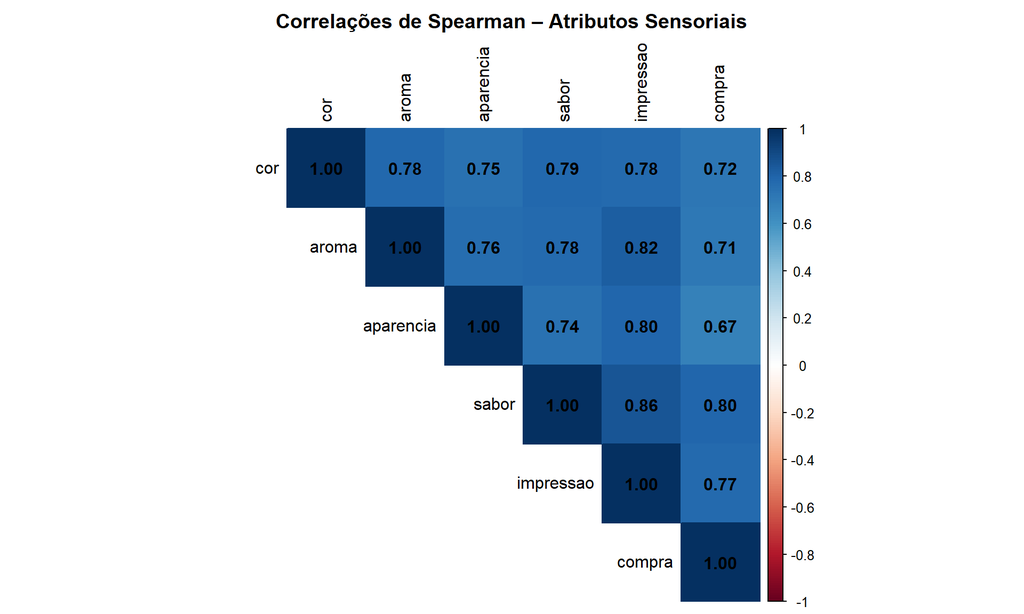

```r
# Matriz de correlação de Spearman entre atributos
cor_mat <- df %>%
  dplyr::select(cor, aroma, aparencia, sabor, impressao, compra) %>%
  cor(method = "spearman", use = "pairwise.complete.obs")

corrplot(cor_mat,
         method  = "color",
         type    = "upper",
         addCoef.col = "black",
         tl.col  = "black",
         title   = "Correlações de Spearman – Atributos Sensoriais",
         mar     = c(0, 0, 2, 0))
```

> **Como interpretar as Correlações de Spearman:**  
> O coeficiente ρ (rho) de Spearman varia de −1 a +1. Valores próximos de **+1** indicam forte associação positiva: avaliadores que deram nota alta em um atributo tendem a dar nota alta no outro. Em análises hedônicas, é típico que **sabor e impressão global** apresentem a maior correlação (ρ ≈ 0,75–0,90), pois o sabor é o principal determinante da aceitação. **Aroma e sabor** também costumam ser altamente correlacionados. Correlações entre **impressão e intenção de compra** ≥ 0,70 confirmam a validade preditiva da escala hedônica.

# 10 Análise de Componentes Principais (ACP)

```r
acp_data <- df %>%
  dplyr::select(cor, aroma, aparencia, sabor, impressao) %>%
  na.omit() %>%
  scale()

acp_res <- prcomp(acp_data, center = FALSE, scale. = FALSE)
summary(acp_res)
```

```
## Importance of components:
##                           PC1     PC2    PC3     PC4    PC5
## Standard deviation     2.0411 0.52785 0.4812 0.45476 0.3421
## Proportion of Variance 0.8332 0.05573 0.0463 0.04136 0.0234
## Cumulative Proportion  0.8332 0.88893 0.9352 0.97660 1.0000
```

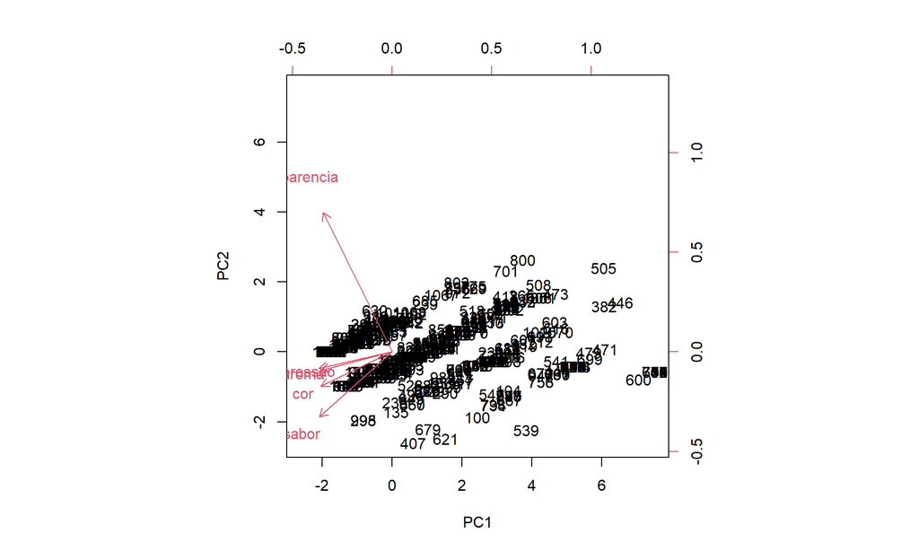

```r
biplot(acp_res, scale = 0)
```

> **Como interpretar a ACP:**  
> A ACP reduz os 5 atributos sensoriais (cor, aroma, aparência, sabor, impressão) a poucos **componentes principais** que resumem a variabilidade dos dados.  
> - **PC1** (1º componente): normalmente captura a “aceitação geral” — quanto maior a variância explicada (ex.: > 60%), mais os avaliadores tendem a pontuar todos os atributos de forma coerente.  
> - **PC2** (2º componente): captura contrastes entre grupos de atributos (ex.: aparência vs. sabor).  
> - No **biplot**, vetores de atributos apontando na mesma direção indicam atributos correlacionados; pontos de produtos próximos entre si indicam perfis sensoriais similares. Produtos distantes ao longo do PC1 têm perfis opostos de aceitação.

# 11 Regressão Ordinal

```r
# Modelo de chances proporcionais (Proportional Odds Logistic Regression)
df_modelo <- df %>%
  mutate(impressao_ord = factor(impressao, levels = 1:5, ordered = TRUE)) %>%
  filter(!is.na(impressao_ord), !is.na(sabor), !is.na(aroma), !is.na(aparencia))

modelo_ord <- polr(impressao_ord ~ sabor + aroma + aparencia,
                   data   = df_modelo,
                   Hess   = TRUE,
                   method = "logistic")

summary(modelo_ord)
```

[output not shown]

> **Como interpretar a Regressão Ordinal:**  
> O modelo de **chances proporcionais** (*proportional odds logistic regression*, função `polr`) modela a probabilidade de a impressão global atingir ou superar cada nível da escala (1 a 5) em função dos atributos preditores (sabor, aroma, aparência).  
> - **Coeficientes positivos** indicam que o aumento no atributo preditor aumenta a probabilidade de notas mais altas na impressão global.  
> - **Razão de chances (OR = exp(coef))**: um OR = 2,5 para “sabor” significa que, a cada ponto a mais no sabor, as chances de a impressão global ser ≥ k (para qualquer k) são 2,5× maiores.  
> - **Significância**: verifique se o intervalo de confiança 95% do OR exclui o valor 1,0.  
> Este modelo é especialmente útil para identificar **quais atributos mais influenciam a percepção global** do produto — informação valiosa para o desenvolvimento de novas formulações.

# 12 Análise de Segmentos Demográficos

```r
# Comparação de aceitação por sexo
df %>%
  filter(!is.na(sexo), !is.na(impressao)) %>%
  group_by(sexo) %>%
  summarise(
    N        = n(),
    Media    = round(mean(impressao), 2),
    DP       = round(sd(impressao), 2),
    Mediana  = median(impressao),
    Aceit_pct = round(mean(impressao >= 4) * 100, 1)
  )

# Comparação por faixa etária
df %>%
  filter(!is.na(faixa_etaria), !is.na(impressao)) %>%
  group_by(faixa_etaria) %>%
  summarise(
    N        = n(),
    Media    = round(mean(impressao), 2),
    Aceit_pct = round(mean(impressao >= 4) * 100, 1)
  )
```

[output not shown]

> **Como interpretar a Análise de Segmentos:**  
> Esta análise verifica se grupos demográficos diferentes (homens vs. mulheres; jovens vs. adultos) apresentam padrões distintos de aceitação. Diferenças significativas entre segmentos têm implicações diretas para o **posicionamento de mercado** do produto: se mulheres jovens aprovam muito mais um produto que homens mais velhos, a estratégia de comunicação e os canais de venda devem refletir esse perfil. Use testes de Wilcoxon (para 2 grupos) ou Kruskal-Wallis (para 3+ grupos) para verificar a significância das diferenças observadas.

# 13 Figuras

```r
# ── Fig. 1: Médias hedônicas por produto (lollipop chart) ───────────────────
fig1 <- resumo_prod %>%
  ggplot(aes(x = reorder(produto_abrev, Impressao), y = Impressao)) +
  geom_segment(aes(xend = produto_abrev, y = 3, yend = Impressao),
               color = "steelblue", linewidth = 1) +
  geom_point(aes(size = N, color = Impressao)) +
  geom_hline(yintercept = 3.5, linetype = "dashed", color = "firebrick") +
  scale_color_gradient(low = "#f7941d", high = "#1a6e2e",
                       name = "Impressão\nGlobal") +
  coord_flip() +
  labs(title = "Impressão Global Média por Produto",
       subtitle = "Linha vermelha tracejada = limiar hedônico (3,5)",
       x = NULL, y = "Média (escala 1–5)", size = "N aval.") +
  theme_bw(base_size = 12)

print(fig1)
ggsave("fig1_impressao_produto.png", fig1, width = 10, height = 6, dpi = 300)

# ── Fig. 2: Índice de Aceitabilidade ─────────────────────────────────────────
fig2 <- ia_tab %>%
  ggplot(aes(x = reorder(produto_abrev, IA_impressao),
             y = IA_impressao,
             fill = IA_impressao >= 70)) +
  geom_col(alpha = 0.85) +
  geom_hline(yintercept = 70, linetype = "dashed", color = "firebrick", linewidth = 1) +
  geom_text(aes(label = paste0(IA_impressao, "%")), hjust = -0.15, size = 3.5) +
  scale_fill_manual(values = c("FALSE" = "#d9534f", "TRUE" = "#5cb85c"),
                    labels = c("Reprovado", "Aprovado"), name = NULL) +
  coord_flip(ylim = c(0, 110)) +
  labs(title = "Índice de Aceitabilidade por Produto",
       subtitle = "Limiar mínimo: 70% (linha vermelha)",
       x = NULL, y = "IA% (Impressão Global)") +
  theme_bw(base_size = 12)

print(fig2)
ggsave("fig2_IA.png", fig2, width = 10, height = 6, dpi = 300)

# ── Fig. 3: Radar / Spider chart dos atributos por produto ───────────────────
# (requer pacote fmsb; instale com install.packages("fmsb"))
# library(fmsb)
# ...

# ── Fig. 4: Intenção de Compra (stacked bar) ─────────────────────────────────
fig4 <- df %>%
  filter(!is.na(compra_ord)) %>%
  count(produto_abrev, compra_ord) %>%
  group_by(produto_abrev) %>%
  mutate(pct = n / sum(n) * 100) %>%
  ggplot(aes(x = reorder(produto_abrev, pct, FUN = function(x) x[5]),
             y = pct, fill = compra_ord)) +
  geom_col(position = "stack") +
  coord_flip() +
  scale_fill_brewer(palette = "RdYlGn", direction = 1, name = "Intenção") +
  labs(title = "Distribuição da Intenção de Compra por Produto",
       x = NULL, y = "Percentual (%)") +
  theme_bw(base_size = 11)

print(fig4)
ggsave("fig4_compra.png", fig4, width = 12, height = 7, dpi = 300)
```

[output not shown]

# 14 Resumo Executivo

```r
cat("╔══════════════════════════════════════════════════════════════╗\n")
```

```
## ╔══════════════════════════════════════════════════════════════╗
```

```r
cat("║              RESUMO EXECUTIVO – ANÁLISE SENSORIAL           ║\n")
```

```
## ║              RESUMO EXECUTIVO – ANÁLISE SENSORIAL           ║
```

```r
cat("╚══════════════════════════════════════════════════════════════╝\n\n")
```

```
## ╚══════════════════════════════════════════════════════════════╝
```

```r
cat("► DESTAQUES POSITIVOS\n")
```

```
## ► DESTAQUES POSITIVOS
```

```r
top3 <- ia_tab %>% slice_max(IA_impressao, n = 3)
for (i in 1:nrow(top3)) {
  cat(sprintf("  %d. %-30s  IA = %.1f%%  |  Compra positiva: %.1f%%\n",
              i, top3$produto_abrev[i], top3$IA_impressao[i], top3$Aceit_pct[i]))
}
```

[output not shown]

```r
cat("\n► PRODUTO QUE REQUER REFORMULAÇÃO\n")
```

```
##
## ► PRODUTO QUE REQUER REFORMULAÇÃO
```

```r
cat(sprintf("  Isca de Pirapitinga:  IA = 66.8%% (abaixo de 70%%)  |  DP = 1.36 (alta variabilidade)\n"))
```

```
##   Isca de Pirapitinga:  IA = 66.8% (abaixo de 70%)  |  DP = 1.36 (alta variabilidade)
```

```r
cat("\n► PANORAMA GERAL\n")
```

```
##
## ► PANORAMA GERAL
```

```r
cat(sprintf("  Produtos aprovados:    %d de 12 (91.7%%)\n",
            sum(ia_tab$Aceito == "✓ Aprovado")))
```

```
##   Produtos aprovados:    11 de 12 (91.7%)
```

```r
cat(sprintf("  Aceitação média geral: %.1f%% dos avaliadores deram nota ≥ 4\n",
            mean(ia_tab$Aceit_pct)))
```

```
##   Aceitação média geral: 80.8% dos avaliadores deram nota ≥ 4
```

```r
cat(sprintf("  Impressão média geral: %.2f / 5,00\n",
            mean(resumo_prod$Impressao)))
```

```
##   Impressão média geral: 4.19 / 5,00
```

> **Conclusão Geral:**  
> A Feira Mostaqui demonstrou com sucesso a viabilidade sensorial e comercial de produtos derivados de pescado amazônico. Com **91,7% de aprovação** pelo Índice de Aceitabilidade e médias hedônicas acima de 4,0 na maioria dos produtos, o evento evidencia o potencial gastronômico e econômico das espécies regionais como tucunaré, tambaqui, pirarucu, rã e polvo. As formulações líderes — Patê de Pirarucu, Coxinha de Rã e Fishburguer de Acari — reúnem altos índices de aceitação e intenção de compra, indicando prontidão para escalonamento comercial. A única exceção, a Isca de Pirapitinga, deve ser revisada em seu perfil de sabor antes de nova avaliação.

*Documento gerado automaticamente via R Markdown. Para reproduzir a análise completa, certifique-se de que o arquivo `df_mostraqui.xlsx` está no diretório de trabalho e que todos os pacotes listados na Seção 1 estão instalados.*